Torch library, often referred to as PyTorch, is an open-source machine learning framework primarily used for deep learning tasks. It is known for its flexibility and dynamic computation graph, which allows for easy model development and experimentation. PyTorch provides a wide range of tools and modules for building neural networks, conducting research in machine learning, and performing various tensor operations efficiently. It has gained popularity among researchers and practitioners for its user-friendly interface, extensive community support, and seamless integration with hardware accelerators like GPUs, making it a powerful choice for developing and deploying machine learning models.

[figure not shown]

# torch.nn

The $\textbf{torch.nn}$ package is a fundamental component of the PyTorch library, and it stands for "neural networks." It provides a vast array of classes and modules to help you build and train neural networks for various machine learning and deep learning tasks.

Here are some key components and functionalities of the torch.nn package:

**Module Parameters**: Neural network parameters (e.g., weights and biases) are automatically registered when created within an nn.Module, allowing for easy access and optimization.

**Containers**: You can use container classes like nn.Sequential to create composite neural network models by stacking layers sequentially.

**Custom Layers**: You can define custom neural network layers by subclassing nn.Module and implementing the forward pass logic.

**Initialization**: torch.nn provides methods for initializing neural network weights, which is crucial for training deep models effectively.

**Loss Functions**: It offers a wide range of loss functions such as mean squared error (nn.MSELoss), cross-entropy loss (nn.CrossEntropyLoss), etc., for different types of tasks.

**Activation Functions**: PyTorch provides various activation functions like ReLU, sigmoid, and tanh, which can be applied to the output of layers.

**Normalization**: Modules like batch normalization (nn.BatchNorm) and layer normalization (nn.LayerNorm) are available for improving the convergence and training stability of neural networks.

**Dropout**: PyTorch supports dropout layers (nn.Dropout) to prevent overfitting by randomly dropping out units during training.

**RNN and LSTM**: It includes recurrent neural network (RNN) and long short-term memory (LSTM) implementations for sequence modeling tasks.

**Data Parallelism**: nn.DataParallel can be used to easily parallelize the training process across multiple GPUs.

**Loss Reduction**: You can specify how losses should be aggregated in case of multiple samples (e.g., mean or sum) using the reduction parameter in loss functions.

# torch.optim

The $\textbf{torch.optim}$ module in PyTorch is a package that provides various optimization algorithms commonly used for training neural networks.

It plays a crucial role in the training process by updating the model's parameters to minimize the loss function during the training iterations.

Here are some key features and functionalities of the torch.optim module

1. Optimization Algorithms
2. Parameter Grouping
3. Learning Rate Scheduling
4. Gradient Clipping
5. Optimizer State

$\textbf{torch.optim}$ is designed to work seamlessly with the neural network modules from the $\textbf{torch.nn}$ package. You can easily connect your model's parameters to the optimizer.

# torch.autograd

**torch.autograd** is a fundamental component of PyTorch that provides automatic differentiation capabilities. It is a crucial feature for training neural networks using techniques like backpropagation, as it automatically computes gradients of tensors with respect to some scalar value (typically a loss function). Here are key points about **torch.autograd**:

**Automatic Differentiation**: Automatic differentiation is a technique that allows you to compute gradients (derivatives) of functions efficiently. In deep learning, this is used to compute gradients of the loss function with respect to the model's parameters, which are then used to update the parameters during training.

**Dynamic Computational Graphs**: PyTorch uses a dynamic computational graph, which means that the graph is built on-the-fly as operations are performed on tensors. This is in contrast to static computational graphs used in some other deep learning frameworks. Dynamic graphs are more flexible and intuitive, making it easier to work with variable-length sequences and dynamic structures.

**Tensors with Gradients**: When you create tensors in PyTorch, you can set the requires_grad attribute to True. This indicates that you want to track the operations performed on that tensor and calculate gradients with respect to it. For example:

[figure not shown]

# Torch Basics

```python
import torch
torch.__version__
```

```
'1.11.0'
```

`torch.tensor` is a function in PyTorch used to create multi-dimensional tensors, which are fundamental data structures in PyTorch for storing and manipulating data.

Tensors are similar to NumPy arrays but are designed to work efficiently on GPUs, making them a fundamental building block for deep learning and numerical computing tasks.

Here's how you can use `torch.tensor`:

```python
# initializing with pre-defined values
# Create a tensor from a list or NumPy array

x = torch.tensor([5.5, 3])
print(x)
```

```
tensor([5.5000, 3.0000])
```

```python
# Converting from numpy to tensor

import numpy as np
x_np = np.ones((3,3))
x_py = torch.from_numpy(x_np)
print(x_np,x_py)
```

```
[[1. 1. 1.]
 [1. 1. 1.]
 [1. 1. 1.]] tensor([[1., 1., 1.],
        [1., 1., 1.],
        [1., 1., 1.]], dtype=torch.float64)
```

```python
# Create a tensor with random values of a specified shape


x = torch.rand(5, 3)
print(x)
```

```
tensor([[0.2007, 0.5014, 0.3139],
        [0.4654, 0.1612, 0.1568],
        [0.2083, 0.3289, 0.1054],
        [0.9192, 0.4008, 0.9302],
        [0.6558, 0.0766, 0.8460]])
```

```python
# Create a tensor with a specific data type
float_tensor = torch.tensor([1.0, 2.0, 3.0], dtype=torch.float32)
print(float_tensor)
```

```
tensor([1., 2., 3.])
```

```python
#Create a tensor with a zeros

x = torch.zeros(5, 3, dtype=torch.long)
print(x)
```

```
tensor([[0, 0, 0],
        [0, 0, 0],
        [0, 0, 0],
        [0, 0, 0],
        [0, 0, 0]])
```

```python
# You can also create tensors from other existing tensors
new_tensor = torch.clone(x)
print(new_tensor)


print('Address:')
print(id(x))
print(id(new_tensor))
```

```
tensor([[0, 0, 0],
        [0, 0, 0],
        [0, 0, 0],
        [0, 0, 0],
        [0, 0, 0]])
Address:
140303351772640
140303243364368
```

```python
print(x.size()) # size of matrix
```

[output not shown]

```python
print(x.shape)
```

```
torch.Size([5, 3])
```

```python
# Create a tensor with shape (1, 3, 1, 4, 1)
tensor = torch.randn(1, 3, 1, 4, 1)

# Squeeze the tensor to remove dimensions with size 1
squeezed_tensor = tensor.squeeze()

print("Original Tensor Shape:", tensor.shape)
print("Squeezed Tensor Shape:", squeezed_tensor.shape)
```

```
Original Tensor Shape: torch.Size([1, 3, 1, 4, 1])
Squeezed Tensor Shape: torch.Size([3, 4])
```

```python
import torch

# Create a tensor with shape (3, 4)
tensor = torch.randn(3, 4)

# Unsqueeze the tensor to add a new dimension at position 1
unsqueeze_tensor = tensor.unsqueeze(1)

print("Original Tensor Shape:", tensor.shape)
print("Unsqueezed Tensor Shape:", unsqueeze_tensor.shape)
```

```
Original Tensor Shape: torch.Size([3, 4])
Unsqueezed Tensor Shape: torch.Size([3, 1, 4])
```

```python
# Different syntaxes for operations
# Eg: Addition

# 1
x = torch.ones(5, 3)
y = torch.rand(5, 3)
print(x + y)

# 2
print(torch.add(x, y))

# 3
result = torch.empty(5, 3)
torch.add(x, y, out=result)
print(result)

# 4
# adds x to y
y.add_(x) # in-place operation
print(y)
```

```
tensor([[1.0367, 1.1256, 1.7606],
        [1.2612, 1.6099, 1.0621],
        [1.3935, 1.9878, 1.9843],
        [1.0487, 1.3814, 1.2449],
        [1.9552, 1.4317, 1.5542]])
tensor([[1.0367, 1.1256, 1.7606],
        [1.2612, 1.6099, 1.0621],
        [1.3935, 1.9878, 1.9843],
        [1.0487, 1.3814, 1.2449],
        [1.9552, 1.4317, 1.5542]])
tensor([[1.0367, 1.1256, 1.7606],
        [1.2612, 1.6099, 1.0621],
        [1.3935, 1.9878, 1.9843],
        [1.0487, 1.3814, 1.2449],
        [1.9552, 1.4317, 1.5542]])
tensor([[1.0367, 1.1256, 1.7606],
        [1.2612, 1.6099, 1.0621],
        [1.3935, 1.9878, 1.9843],
        [1.0487, 1.3814, 1.2449],
        [1.9552, 1.4317, 1.5542]])
```

```python
print(y[:, 1]) # indexing
```

```
tensor([1.1256, 1.6099, 1.9878, 1.3814, 1.4317])
```

```python
# Resizing/reshaping tensors
x = torch.randn(4, 4)
y = x.view(16)
z = x.view(-1, 8)  # the size -1 is inferred from other dimensions
print(x.size(), y.size(), z.size())
```

```
torch.Size([4, 4]) torch.Size([16]) torch.Size([2, 8])
```

```python
# GPU availiability checking
print(torch.cuda.is_available())
```

```
True
```

```python
torch.cuda.device_count()
```

```
2
```

```python
for i in range(torch.cuda.device_count()):
   print(torch.cuda.get_device_properties(i).name)
   print(torch.cuda.get_device_properties(i))
```

```
Quadro RTX 8000
_CudaDeviceProperties(name='Quadro RTX 8000', major=7, minor=5, total_memory=48601MB, multi_processor_count=72)
Quadro RTX 8000
_CudaDeviceProperties(name='Quadro RTX 8000', major=7, minor=5, total_memory=48598MB, multi_processor_count=72)
```

```python
# CUDA tensor
if torch.cuda.is_available():
    print('GPU is available!')
    device = torch.device("cuda")          # a CUDA device object
    y = torch.ones_like(x, device=device)  # directly create a tensor on GPU
    x = x.to(device)                       # or just use strings ``.to("cuda")``
    z = x + y
    print(z)
    z=z.to("cpu", torch.double) # ``.to`` can also change dtype together!
    print(z)
```

```
GPU is available!
tensor([[ 3.1894,  0.0634,  1.0686,  0.6623],
        [ 0.8871,  2.2230,  1.2424,  1.2709],
        [ 0.6563,  2.6126,  0.9264,  0.4618],
        [ 1.7119, -0.0833,  2.1172,  1.4964]], device='cuda:0')
tensor([[ 3.1894,  0.0634,  1.0686,  0.6623],
        [ 0.8871,  2.2230,  1.2424,  1.2709],
        [ 0.6563,  2.6126,  0.9264,  0.4618],
        [ 1.7119, -0.0833,  2.1172,  1.4964]], dtype=torch.float64)
```

```python
# CUDA tensor
if torch.cuda.is_available():
    print('GPU is available!')
    device = torch.device("cuda:1")          # a CUDA device object
    y = torch.ones_like(x, device=device)  # directly create a tensor on GPU
    print(y)
```

```
GPU is available!
tensor([[1., 1., 1., 1.],
        [1., 1., 1., 1.],
        [1., 1., 1., 1.],
        [1., 1., 1., 1.]], device='cuda:1')
```

# statistical operations

PyTorch provides a variety of statistical operations for tensors, allowing you to compute various statistics such as mean, standard deviation, variance, minimum, maximum, and more. Here are some commonly used statistical operations in PyTorch:

```python
tensor = torch.randn(3, 4)

# Mean of all elements
mean = torch.mean(tensor)

# Mean along dimension 0
mean_along_dim = torch.mean(tensor, dim=0)

print(mean)
print(mean_along_dim)
```

```
tensor(-0.2100)
tensor([-0.2162,  0.4667, -0.5900, -0.5003])
```

```python
# Variance of all elements
variance = torch.var(tensor)

# Variance along dimension 0
variance_along_dim = torch.var(tensor, dim=0)

print(variance)
print(variance_along_dim)
```

```
tensor(0.3472)
tensor([0.5351, 0.1601, 0.1210, 0.0635])
```

```python
# Standard deviation of all elements
std = torch.std(tensor)

# Standard deviation along dimension 1
std_along_dim = torch.std(tensor, dim=1)

print(std)
print(std_along_dim)
```

```
tensor(0.5892)
tensor([0.5607, 0.7858, 0.4790])
```

# Autograd: Automatic Differentiation

$\textbf{torch.autograd}$ is a key component of PyTorch that enables automatic differentiation, allowing you to compute gradients of tensors with respect to other tensors.

This is crucial for training neural networks using gradient-based optimization algorithms like stochastic gradient descent (SGD). Here's a simple example to demonstrate how torch.autograd works:

Consider the following expression for the demo:

$z=(x+y)$

$f=z^2+t^4$

$\frac{\partial f}{\partial x}=2(x+y)$

$\frac{\partial f}{\partial y}=2(x+y)$

$\frac{\partial f}{\partial t}=4t^3$

```python
import torch

# Create two tensors with requires_grad=True to track operations for gradient computation
x = torch.tensor(2.0, requires_grad=True)
y = torch.tensor(3.0, requires_grad=True)
t = torch.tensor(3.0, requires_grad=True)

# Define a simple computation using these tensors
z = x + y
f = z * z+ t**4

# Let's compute gradients with respect to x and y
f.backward()

# Gradients are computed and stored in the .grad attribute of the tensors
gradient_x = x.grad
gradient_y = y.grad
gradient_t = t.grad

print("Result:", f)
print("Gradient with respect to x:", gradient_x)
print("Gradient with respect to y:", gradient_y)
print("Gradient with respect to t:", gradient_t)
```

```
Result: tensor(106., grad_fn=<AddBackward0>)
Gradient with respect to x: tensor(10.)
Gradient with respect to y: tensor(10.)
Gradient with respect to t: tensor(108.)
```

```python
make_dot(f)
```

[figure not shown]

# Solving minimization problem with the help of gradients

We are finding min value for the given function $y=f(x)$.

$y=f(x) = ax^2 + bx + c$

```python
import torch

# Define the function y = x^2 -3x +2
def function(x):
    return x**2 - 3 * x +2

# Initial guess for the minimum
x = torch.tensor(0.0, requires_grad=True)

# Learning rate and number of iterations for gradient descent
learning_rate = 0.01
num_iterations = 500

# Gradient descent loop

x_cal=[]
y_cal=[]

for i in range(num_iterations):
    # Calculate the value of the function at the current point
    y = function(x)

    # Compute the gradient of the function with respect to x
    gradient = torch.autograd.grad(y, x)[0]

    # Update the value of x using gradient descent
    x = x - learning_rate * gradient


    x_cal.append(x.item())
    y_cal.append(function(x).item())

# The optimized value of x should be the minimum value of the function
minimum_value = function(x).item()

print("Minimum Value:", minimum_value)
print("Optimized x:", x.item())
```

```
Minimum Value: -0.25
Optimized x: 1.4999384880065918
```

[figure not shown]

```python
# Import libraries
import matplotlib.pyplot as plt
import numpy as np

# Creating vectors X and Y
x = np.linspace(-1, 4, 1000)
y = x*x-3*x+2

fig = plt.figure(figsize = (15, 15))
# Create the plot
plt.plot(x, y)
plt.plot(min_x,min_y,'*:r',color='g')

plt.plot(x_cal,y_cal,'*:r',color='g')

plt.text(min_x,min_y, '('+str(round(min_x,4))+','+str(round(min_y,4))+')', fontsize = 15,color='g')
plt.axis([0, 4, -1,5])

plt.xlabel('x',fontsize=10)
plt.ylabel('$y=x^2 - 3x + 2$',fontsize=10)

# Show the plot
plt.show()
```

```python
import torch

# Define the function y = 3x^3 + 2x^2 - 4x + 1
def function(x):
    return 3 * x**3 + 2 * x**2 - 4 * x + 1

# Initial guess for the minimum
x = torch.tensor(0.0, requires_grad=True)

# Learning rate and number of iterations for gradient descent
learning_rate = 0.01
num_iterations = 1000


x_cal=[]
y_cal=[]

# Gradient descent loop
for i in range(num_iterations):
    # Calculate the value of the function at the current point
    y = function(x)

    # Compute the gradient of the function with respect to x
    gradient = torch.autograd.grad(y, x)[0]

    # Update the value of x using gradient descent
    x = x - learning_rate * gradient

    x_cal.append(x.item())
    y_cal.append(function(x).item())

# The optimized value of x should be the minimum value of the function
min_y = function(x).item()
min_x=x.item()
print("Minimum Value:", min_y)
print("Optimized x:", min_x)
```

```
Minimum Value: -0.1274256706237793
Optimized x: 0.480506032705307
```

```python
print(min(x_cal),max(x_cal))

print(min(y_cal),max(y_cal))
```

```
0.03999999910593033 0.480506032705307
-0.1274256706237793 0.843392014503479
```

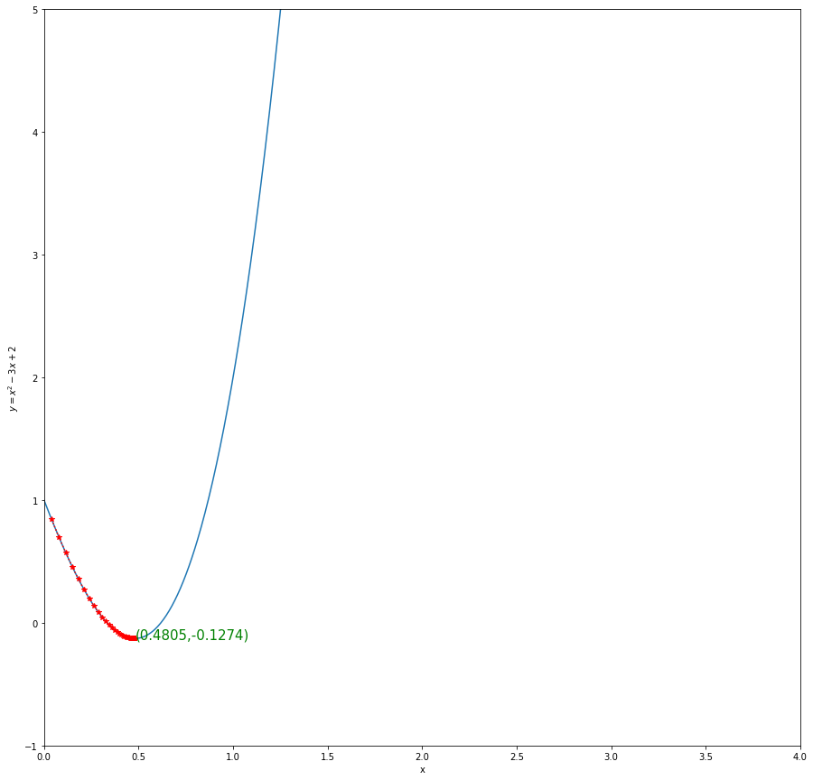

```python
# Import libraries
import matplotlib.pyplot as plt
import numpy as np

# Creating vectors X and Y
x = np.linspace(-1, 4, 1000)
y = 3 * x**3 + 2 * x**2 - 4 * x + 1

fig = plt.figure(figsize = (15, 15))
# Create the plot
plt.plot(x, y)
plt.plot(min_x,min_y,'*:g',color='g')

plt.plot(x_cal,y_cal,'*:r',color='r')

plt.text(min_x,min_y, '('+str(round(min_x,4))+','+str(round(min_y,4))+')', fontsize = 15,color='g')
plt.axis([0, 4, -1,5])

plt.xlabel('x',fontsize=10)
plt.ylabel('$y=x^2 - 3x + 2$',fontsize=10)

# Show the plot
plt.show()
```

# torch.optim

[figure not shown]

```python
import torch
import torch.optim as optim

# Define the coefficients of the quadratic equation: y=f(x) = ax^2 + bx + c
a = torch.tensor(1.0, requires_grad=False)
b = torch.tensor(-3.0, requires_grad=False)
c = torch.tensor(2.0, requires_grad=False)

# Create a variable x with requires_grad=True to track operations for gradient computation
x = torch.tensor(0.0, requires_grad=True)

# Learning rate and number of iterations for gradient descent
learning_rate = 0.1
num_iterations = 10000

# Define the quadratic equation
def equation(x):
    return a * x**2 + b * x + c


# Gradient descent optimizer
optimizer = optim.SGD([x], lr=learning_rate)

# Gradient descent loop
for i in range(num_iterations):
    # Calculate the loss (value of y)
    y = equation(x)

    # Compute the gradient of the loss with respect to x
    optimizer.zero_grad()
    y.backward()

    # Update the value of x using gradient descent
    optimizer.step()

# The optimized value of x should be the root of the equation
min_y=equation(x).item()
min_x = x.item()

print("min-x", min_x)
print('min-y:',min_y)
```

```
min-x 1.499999761581421
min-y: -0.2499997615814209
```

# visualizing the proof

[figure not shown]

```python
# Import libraries
import matplotlib.pyplot as plt
import numpy as np

# Creating vectors X and Y
x = np.linspace(-1, 4, 1000)
y = x*x-3*x+2

fig = plt.figure(figsize = (10, 5))
# Create the plot
plt.plot(x, y)
plt.plot(min_x,min_y,'*:r',color='red')
plt.text(min_x,min_y, '('+str(round(min_x,4))+','+str(round(min_y,4))+')', fontsize = 15,color='g')
plt.axis([0, 4, -1,5])

plt.xlabel('x',fontsize=10)
plt.ylabel('$y=ax^2 + bx + c$',fontsize=10)

# Show the plot
plt.show()
```

# Linear Regression

Linear regression is a fundamental machine learning algorithm used for modeling the relationship between a dependent variable (target) and one or more independent variables (features).

In this example, I'll demonstrate linear regression with a single feature using PyTorch.

We are fitting into cubic polynomial model.

```python
import torch
import torch.optim as optim

# Simulated data
# Generate some random data for x and compute y = ax^3 + bx^2 + cx + d + noise
torch.manual_seed(42)
x = torch.rand(100, 1)
y = 3 * x**3 + 2 * x**2 - 4 * x + 1

# Define the cubic polynomial regression model
class CubicPolynomialRegressionModel(torch.nn.Module):
    def __init__(self):
        super(CubicPolynomialRegressionModel, self).__init__()
        self.a = torch.nn.Parameter(torch.rand(1))
        self.b = torch.nn.Parameter(torch.rand(1))
        self.c = torch.nn.Parameter(torch.rand(1))
        self.d = torch.nn.Parameter(torch.rand(1))

    def forward(self, x):
        return self.a * x**3 + self.b * x**2 + self.c * x + self.d

# Create the model
model = CubicPolynomialRegressionModel()

# Loss function (Mean Squared Error)
criterion = torch.nn.MSELoss()

# Optimizer (Stochastic Gradient Descent)
optimizer = optim.SGD(model.parameters(), lr=0.1)

# Training loop
num_epochs = 3000
loss_list=[]
for epoch in range(num_epochs):

    # Forward pass
    outputs = model(x)

    # Compute the loss
    loss = criterion(outputs, y)
    loss_list.append(loss.item())

    # Backpropagation and optimization
    optimizer.zero_grad()
    loss.backward()
    optimizer.step()

    # Print the loss every 100 epochs
    if (epoch + 1) % 100 == 0:
        print(f'Epoch [{epoch + 1}/{num_epochs}], Loss: {loss.item():.4f}')

# Print the learned parameters (a, b, c, d)
with torch.no_grad():
    a, b, c, d = model.a.item(), model.b.item(), model.c.item(), model.d.item()
    print(f'Learned parameters: a = {a:.4f}, b = {b:.4f}, c = {c:.4f}, d = {d:.4f}')
```

```
Epoch [100/3000], Loss: 0.1357
Epoch [200/3000], Loss: 0.1068
Epoch [300/3000], Loss: 0.0840
Epoch [400/3000], Loss: 0.0661
Epoch [500/3000], Loss: 0.0521
Epoch [600/3000], Loss: 0.0410
Epoch [700/3000], Loss: 0.0323
Epoch [800/3000], Loss: 0.0254
Epoch [900/3000], Loss: 0.0200
Epoch [1000/3000], Loss: 0.0158
Epoch [1100/3000], Loss: 0.0124
Epoch [1200/3000], Loss: 0.0098
Epoch [1300/3000], Loss: 0.0077
Epoch [1400/3000], Loss: 0.0061
Epoch [1500/3000], Loss: 0.0048
Epoch [1600/3000], Loss: 0.0038
Epoch [1700/3000], Loss: 0.0030
Epoch [1800/3000], Loss: 0.0024
Epoch [1900/3000], Loss: 0.0019
Epoch [2000/3000], Loss: 0.0015
Epoch [2100/3000], Loss: 0.0012
Epoch [2200/3000], Loss: 0.0010
Epoch [2300/3000], Loss: 0.0008
Epoch [2400/3000], Loss: 0.0007
Epoch [2500/3000], Loss: 0.0005
Epoch [2600/3000], Loss: 0.0005
Epoch [2700/3000], Loss: 0.0004
Epoch [2800/3000], Loss: 0.0003
Epoch [2900/3000], Loss: 0.0003
Epoch [3000/3000], Loss: 0.0002
Learned parameters: a = 3.4691, b = 1.1183, c = -3.5254, d = 0.9391
```

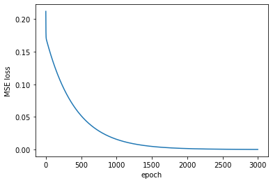

```python
import matplotlib.pyplot as plt
plt.plot(loss_list)
plt.xlabel('epoch')
plt.ylabel('MSE loss')
```

```python
import torch
import torch.optim as optim

# Simulated data
# Generate some random data for x and compute y=3 * x**3 + 2 * x**2 - 4 * x + 1
torch.manual_seed(42)
x = torch.rand(100, 1)
y = 3 * x**3 + 2 * x**2 - 4 * x + 1

x_input=torch.hstack([x*x*x,x*x,x])

# Define the linear regression model
class LinearRegressionModel(torch.nn.Module):
    def __init__(self):
        super(LinearRegressionModel, self).__init__()
        # 3 input feature, one output
        self.linear = torch.nn.Linear(3, 1)

    def forward(self, x):
        return self.linear(x)

# Create the model
model = LinearRegressionModel()

# Loss function (Mean Squared Error)
criterion = torch.nn.MSELoss()

# Optimizer (Stochastic Gradient Descent)
optimizer = optim.SGD(model.parameters(), lr=0.11)

# Training loop
num_epochs = 100000
for epoch in range(num_epochs):
    # Forward pass
    outputs=model(x_input)


    # Compute the loss
    loss = criterion(outputs, y)

    # Backpropagation and optimization
    optimizer.zero_grad()
    loss.backward()
    optimizer.step()

    # Print the loss every 100 epochs
    if (epoch + 1) % 100 == 0:
        print(f'Epoch [{epoch + 1}/{num_epochs}], Loss: {loss.item():.6f}')
```

```
Epoch [100/100000], Loss: 0.138098
Epoch [200/100000], Loss: 0.106092
Epoch [300/100000], Loss: 0.081518
Epoch [400/100000], Loss: 0.062641
Epoch [500/100000], Loss: 0.048142
Epoch [600/100000], Loss: 0.037005
Epoch [700/100000], Loss: 0.028451
Epoch [800/100000], Loss: 0.021880
Epoch [900/100000], Loss: 0.016832
Epoch [1000/100000], Loss: 0.012955
Epoch [1100/100000], Loss: 0.009977
Epoch [1200/100000], Loss: 0.007690
Epoch [1300/100000], Loss: 0.005932
Epoch [1400/100000], Loss: 0.004582
Epoch [1500/100000], Loss: 0.003546
Epoch [1600/100000], Loss: 0.002749
Epoch [1700/100000], Loss: 0.002137
Epoch [1800/100000], Loss: 0.001667
Epoch [1900/100000], Loss: 0.001305
Epoch [2000/100000], Loss: 0.001028
Epoch [2100/100000], Loss: 0.000815
Epoch [2200/100000], Loss: 0.000651
Epoch [2300/100000], Loss: 0.000525
Epoch [2400/100000], Loss: 0.000428
Epoch [2500/100000], Loss: 0.000353
Epoch [2600/100000], Loss: 0.000296
Epoch [2700/100000], Loss: 0.000251
Epoch [2800/100000], Loss: 0.000217
Epoch [2900/100000], Loss: 0.000191
Epoch [3000/100000], Loss: 0.000171
Epoch [3100/100000], Loss: 0.000155
Epoch [3200/100000], Loss: 0.000143
Epoch [3300/100000], Loss: 0.000134
Epoch [3400/100000], Loss: 0.000126
Epoch [3500/100000], Loss: 0.000121
Epoch [3600/100000], Loss: 0.000116
Epoch [3700/100000], Loss: 0.000113
Epoch [3800/100000], Loss: 0.000110
Epoch [3900/100000], Loss: 0.000107
Epoch [4000/100000], Loss: 0.000106
```

[output cut: 945 more lines]

```
Epoch [98600/100000], Loss: 0.000002
Epoch [98700/100000], Loss: 0.000002
Epoch [98800/100000], Loss: 0.000002
Epoch [98900/100000], Loss: 0.000002
Epoch [99000/100000], Loss: 0.000002
Epoch [99100/100000], Loss: 0.000002
Epoch [99200/100000], Loss: 0.000002
Epoch [99300/100000], Loss: 0.000002
Epoch [99400/100000], Loss: 0.000002
Epoch [99500/100000], Loss: 0.000002
Epoch [99600/100000], Loss: 0.000002
Epoch [99700/100000], Loss: 0.000002
Epoch [99800/100000], Loss: 0.000002
Epoch [99900/100000], Loss: 0.000002
Epoch [100000/100000], Loss: 0.000002
```

```python
for i in model.parameters():
    print(i)
```

[output not shown]

```python
# Print the learned parameters (a and b)
with torch.no_grad():
    W, b = model.linear.weight,model.linear.bias
    print('Weight:',W)
    print('Bias',b)
```

```
Weight: Parameter containing:
tensor([[ 3.0682,  1.8947, -3.9557]], requires_grad=True)
Bias Parameter containing:
tensor([0.9958], requires_grad=True)
```

# Optimizers Demo

```python
import torch
import torch.optim as optim

# Simulated data
# Generate some random data for x and compute y=3 * x**3 + 2 * x**2 - 4 * x + 1
torch.manual_seed(42)
x = torch.rand(100, 1)
y = 3 * x**3 + 2 * x**2 - 4 * x + 1

x_input=torch.hstack([x*x*x,x*x,x])
```

```python
# Define the linear regression model
class LinearRegressionModel(torch.nn.Module):
    def __init__(self):
        super(LinearRegressionModel, self).__init__()
        # 3 input feature, one output
        self.linear = torch.nn.Linear(3, 1)

    def forward(self, x):
        return self.linear(x)
```

```python
num_epochs = 10000
```

# Stochastic Gradient Descent (SGD):

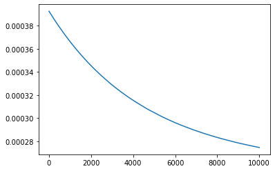

```python
# Optimizer (SGD)
optimizer_sgd = optim.SGD(model_for_SGD.parameters(), lr=0.01)

# Training loop
losses_sgd = []
for epoch in range(num_epochs):
    optimizer_sgd.zero_grad()
    outputs = model_for_SGD(x_input)
    loss = criterion(outputs, y)
    loss.backward()
    optimizer_sgd.step()
    losses_sgd.append(loss.item())

# Plot the loss
plt.plot(losses_sgd, label='SGD')
```

# Adam Optimizer:

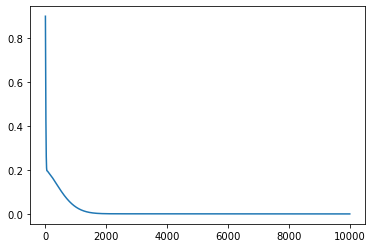

```python
model_for_Adam = LinearRegressionModel()


# Optimizer (Adam)
optimizer_adam = optim.Adam(model_for_Adam.parameters(), lr=0.01)

# Training loop
losses_adam = []
for epoch in range(num_epochs):
    optimizer_adam.zero_grad()
    outputs = model_for_Adam(x_input)
    loss = criterion(outputs, y)
    loss.backward()
    optimizer_adam.step()
    losses_adam.append(loss.item())

# Plot the loss
plt.plot(losses_adam, label='Adam')
```

# RMSprop Optimizer:

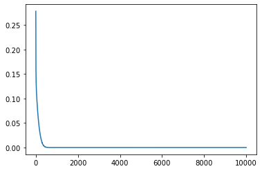

```python
model_for_RMSprop = LinearRegressionModel()
# Optimizer (RMSprop)
optimizer_rmsprop = optim.RMSprop(model_for_RMSprop.parameters(), lr=0.01)

# Training loop
losses_rmsprop = []
for epoch in range(num_epochs):
    optimizer_rmsprop.zero_grad()
    outputs = model_for_RMSprop(x_input)
    loss = criterion(outputs, y)
    loss.backward()
    optimizer_rmsprop.step()
    losses_rmsprop.append(loss.item())

# Plot the loss
plt.plot(losses_rmsprop, label='RMSprop')
```

After training, you can visualize the loss curves for each optimizer:

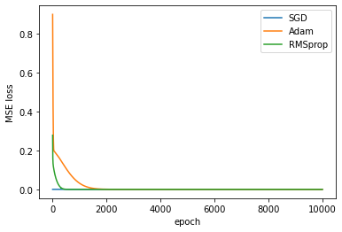

```python
plt.plot(losses_sgd, label='SGD')
plt.plot(losses_adam, label='Adam')
plt.plot(losses_rmsprop, label='RMSprop')
#plt.xlim([0, 2500])
plt.xlabel('epoch')
plt.ylabel('MSE loss')

plt.legend(['SGD','Adam','RMSprop'])
```

```python
print('SGD')

for i in model_for_SGD.parameters():
    print(i)


print('RMSProp')

for i in model_for_RMSprop.parameters():
    print(i)

print('Adam')
for i in model_for_Adam.parameters():
    print(i)
```

```
SGD
Parameter containing:
tensor([[ 3.8190,  0.6904, -3.4185]], requires_grad=True)
Parameter containing:
tensor([0.9405], requires_grad=True)
RMSProp
Parameter containing:
tensor([[ 3.0615,  1.8921, -3.9614]], requires_grad=True)
Parameter containing:
tensor([0.9909], requires_grad=True)
Adam
Parameter containing:
tensor([[ 3.0022,  1.9966, -3.9985]], requires_grad=True)
Parameter containing:
tensor([0.9999], requires_grad=True)
```